# Reproducible Research Peer Assesment 1

first we will load the data, create correct date type and remove NAs

```r
library(ggplot2)
library(plyr)
adf <- read.csv(unzip('activity.zip'))
adf$date <- as.POSIXlt(adf[, 2])
actdf <- adf[!is.na(adf[,1]),]
```

# What is the mean total number of steps per day?

Here is a histogram of the steps taken per day

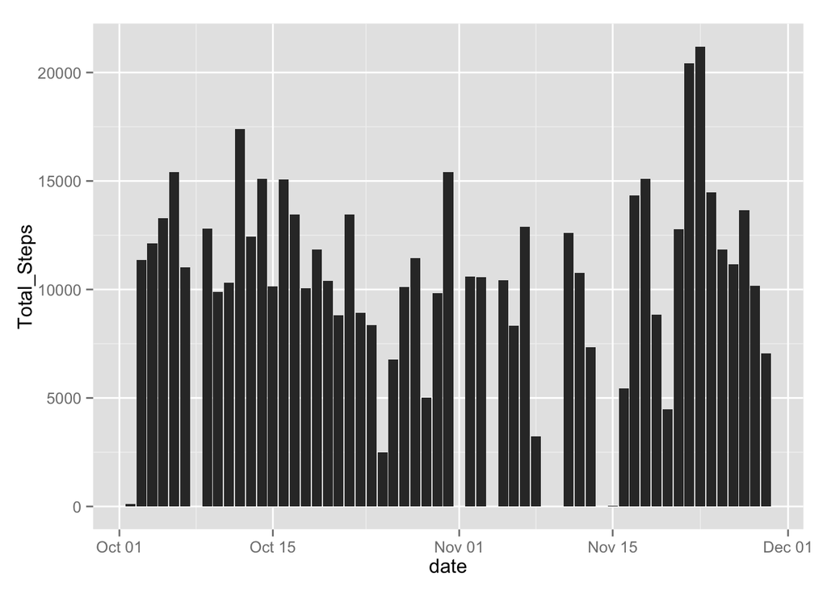

```r
actsummary <- ddply(actdf, .(date), summarize, Total_Steps = sum(steps))
actsummary <- actsummary[order(actsummary$date),]

p <- ggplot(actsummary, aes(date, Total_Steps)) + geom_histogram(stat = 'identity')
p
```

The mean number of steps per day is

```r
mean(actsummary$Total_Steps)
```

```
## [1] 10766
```

And the median number of steps per day is

```r
median(actsummary$Total_Steps)
```

```
## [1] 10765
```

# What is the average daily activity pattern?

Here is a plot of the average steps taken during each time interval

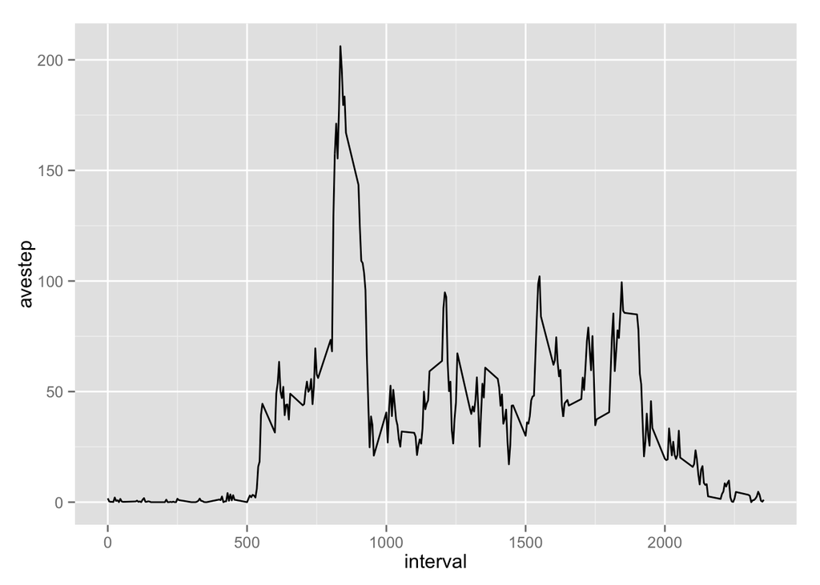

```r
q2summary <- ddply(actdf, .(interval), summarize, avestep = mean(steps))
q2summary$interval <- as.integer(q2summary$interval)
q2p <- ggplot(q2summary, aes(interval, avestep)) + geom_line()
q2p
```

The interval that takes the most steps on average is

```r
maxfind <- order(q2summary$avestep, decreasing = TRUE)
q2summary[maxfind[1],1]
```

```
## [1] 835
```

# Inputting Missing Values

```r
for (i in which(sapply(adf, is.numeric))) {
    adf[is.na(adf[, i]), i] <- mean(adf[, i],  na.rm = TRUE)
}
```

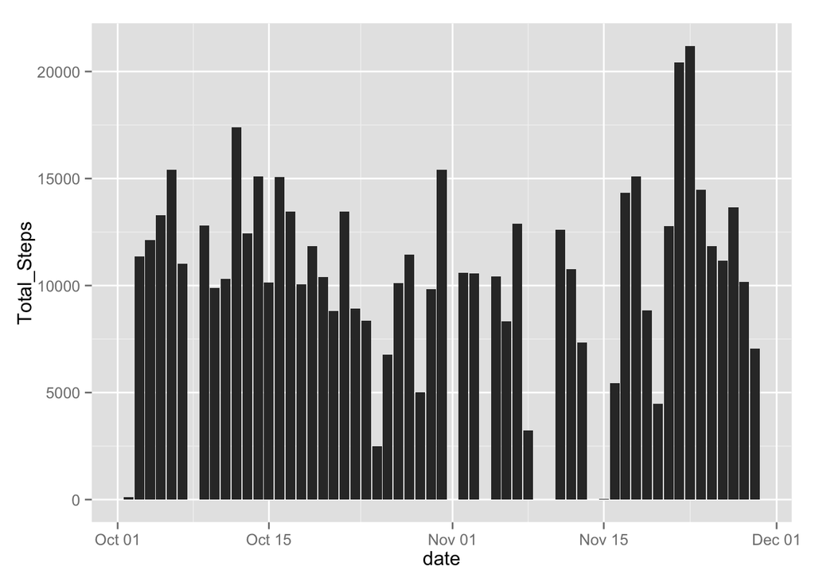

```r
asummary <- ddply(adf, .(date), summarize, Total_Steps = sum(steps))
asummary <- asummary[order(asummary$date),]

p2 <- ggplot(actsummary, aes(date, Total_Steps)) + geom_histogram(stat = 'identity')
p2
```

The mean number of steps per day is

```r
mean(asummary$Total_Steps)
```

```
## [1] 10766
```

And the median number of steps per day is

```r
median(asummary$Total_Steps)
```

```
## [1] 10766
```

the mean number is not affected because of the method of imputing draws from mean steps per day. The median increases because a day with NAs went from below the median to above, this caused the median to be the same as the mean.

# Are there differences in activity patterns between weekdays and weekends?

```r
adf$date <- as.POSIXct(adf[, 2])
adf <- ddply(adf, .(steps,date,interval), transform, weekday = weekdays(date))
adf <- arrange(adf, weekday)
weekends <-adf[10369:14976,]
weekday <- adf[1:10368,]
```

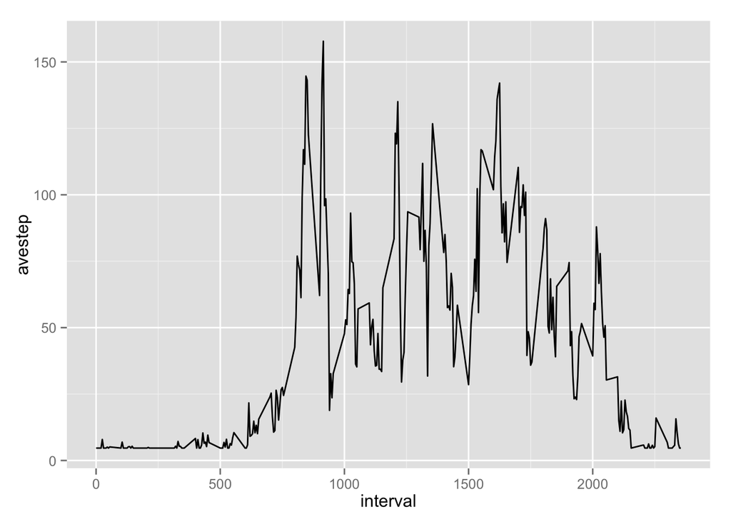

```r
lastplot <- ddply(weekends, .(interval), summarize, avestep = mean(steps))
lastplot2 <- ddply(weekday, .(interval), summarize, avestep =mean(steps))

plotty <- ggplot(lastplot, aes(interval,avestep)) + geom_line()
plotty2 <- ggplot(lastplot2, aes(interval,avestep)) + geom_line()

plotty
```

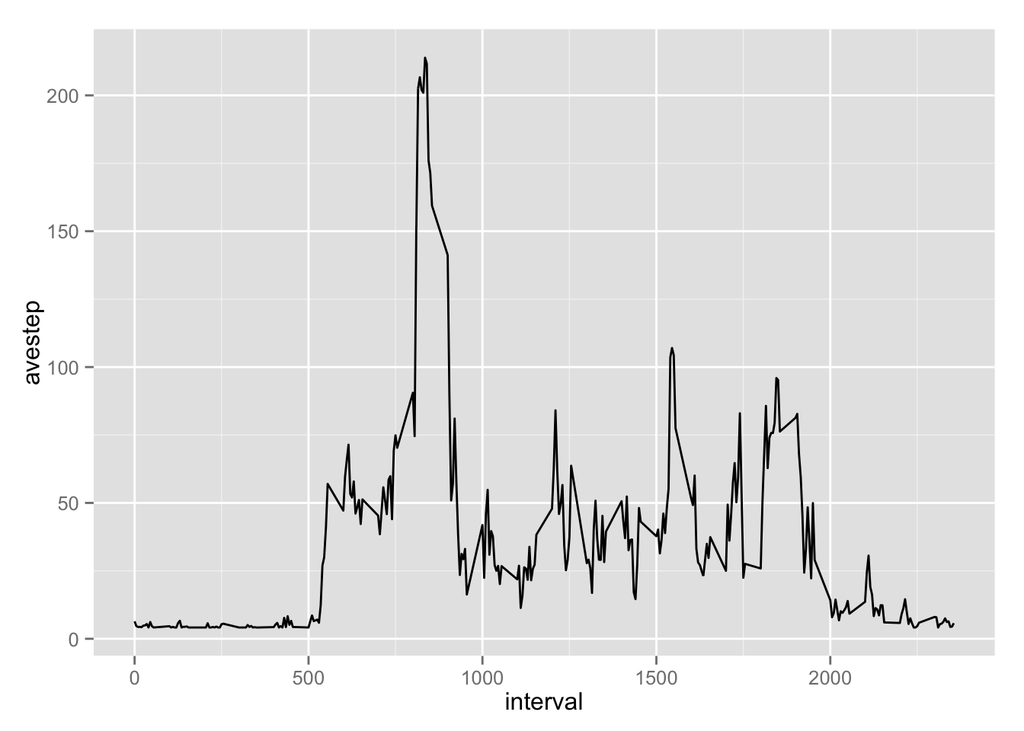

```r
plotty2
```